# Intuitive Theories of Mind - Reproducibility

[figure not shown]

In this notebook we reproduce the results in the paper [Intuitive Theories of Mind: A Rational Approach to False Belief](http://web.mit.edu/cocosci/Papers/pos785-goodman.pdf).

Seeks to explain the results of the *False Belief* task.

[figure not shown]

Children's response changes in the third or fourth year of life, from:

- **Copy-Theorist (CT), i.e. beliefs are always consistent with the world**: *"Sally looks in the new location"*, to
- **Perspective-Theorist (PT), i.e. beliefs are mediated by perspective, and can be false**: *"Sally looks in the original location"*

*Why does this transition happen?*

- Is it because children are *irrational*?
- Or, rather, is it the result of *rational* behaviour?

[figure not shown]

The paper shows that the transition from a CT position to a PT position arises naturally in a Bayesian setting, thus providing evidence that young children are acting rationally.

[figure not shown]

## Copy-Theorist Model (CT)

*"Sally knows what I know."*

[figure not shown]

## Perspective-Theorist Model (PT)

*"Sally does NOT necessarily know what I know!"*

[figure not shown]

# Code

```python
import numpy as np
import pandas as pd
import matplotlib.pyplot as plt
import seaborn as sns
from scipy.stats import beta
import pyjags
```

```python
CT_THEORY = 0
PT_THEORY = 1
THEORY_ID_TO_NAME = {CT_THEORY: "CT", PT_THEORY: "PT"}
```

# CT Model Code

[figure not shown]

```python
CT_model_code = """
model {
    V ~ dbern(0.5)
    W ~ dbern(0.5)

    B <- W

    Epsilon ~ dbeta(1,10)
    D ~ dbern(1 - Epsilon)
    A ~ dbern(0.5 * (1 - D) + D * B)
}
"""
```

# PT Model Code

[figure not shown]

```python
PT_model_code = """
model {
    V ~ dbern(0.5)
    W ~ dbern(0.5)

    Gamma ~ dbeta(1,5)
    E_gamma ~ dbern(Gamma)
    B <- E_gamma * (1 - V) + V * W

    Epsilon ~ dbeta(1,10)
    D ~ dbern(1 - Epsilon)
    A ~ dbern(0.5 * (1 - D) + D * B)
}
"""
```

# Figure 2 (b)

[figure not shown]

The purpose of this plot it to show that the CT model and the PT model make different predictions when presented with the *false belief* task: The PT model predicts that Sally will look for her toy in the original location ($A = 0$), whereas the CT model predicts that Sally will look for her toy in the **new** location ($A = 1$).

We'll use JAGS to draw samples from $P(A\ |\ W=1, V=0, Theory)$. Exact computation would require marginalizing out $\epsilon, \gamma, D, B$, which is difficult and shows the benefits of using a MCMC sampler for inference (Gibbs sampling is a particular form of MCMC).

We use 4 chains with 1000 burn-in steps and draw 1000 samples from each chain.

# Code

```
sampling: iterations 4000 of 4000, elapsed 0:00:00, remaining 0:00:00
sampling: iterations 4000 of 4000, elapsed 0:00:00, remaining 0:00:00
```

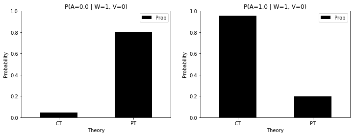

```python
def figure_2_b():
    # This data frame will have 4 rows: one for each combination of Theory \in [CT_THEORY, PT_THEORY] and A \in [0, 1]
    # The row corresponding to theory and a contains P(A=a | W=1, V=0, Theory=theory)
    # Using a dataframe to store these 4 rows is convenient because we can then use
    # the pandas.DataFrame.plot method to do nice plots.
    Prob_A_given_W1_V0_Theory = pd.DataFrame(columns=['Theory', 'A', 'Prob'])

    # Fix w and v to the value we care about
    w = 1
    v = 0
    for theory in [CT_THEORY, PT_THEORY]:
        model_code = CT_model_code if theory == CT_THEORY else PT_model_code
        # Sample with JAGS from P(A | W=1, V=0, Theory=theory)
        model = pyjags.Model(model_code, data=dict(W=w, V=v), chains=4, adapt=1000)
        samples = model.sample(1000, vars=['A'])
        for a in [0, 1]:
            # Compute P(A=a | W=1, V=0, Theory=theory) from samples
            prob = np.mean(samples['A'] == a)
            # Add this row corresponding to (theory, a) to the dataframe.
            Prob_A_given_W1_V0_Theory =  Prob_A_given_W1_V0_Theory.append(
                {'Theory' : theory, 'A' : a, 'Prob' : prob}, ignore_index=True)

    # Do a nice plot by using the Prob_A_given_W1_V0_Theory dataframe.
    fig, axes = plt.subplots(nrows=1, ncols=2, figsize=(12,4))#, sharey=True)
    grouped = Prob_A_given_W1_V0_Theory.groupby('A')
    for (group, ax) in zip(grouped, axes.flatten()):
        a, group = group
        my_plt = group.plot(y='Prob', x='Theory', kind='bar', ax=ax, color='k')
        ax.set_title(f"P(A={a} | W={w}, V={v})")
        ax.set_xticklabels(THEORY_ID_TO_NAME.values(), rotation=0)
        ax.set_ylabel("Probability")
        ax.set_ylim((0, 1))

    plt.show()

figure_2_b()
```

# Figure 2 (c)

[figure not shown]

These plots show the probability of each explanation. This requires computing $P(D=d, B=b, E_\gamma=e_\gamma | W=1, V=1, A=a)$, which involves marginalizing out the continuous variable $\epsilon$, so JAGS is convenient.

# Figure 2 (c), CT

[figure not shown]

# Code

```
adapting: iterations 4000 of 4000, elapsed 0:00:00, remaining 0:00:00
sampling: iterations 4000 of 4000, elapsed 0:00:00, remaining 0:00:00
adapting: iterations 4000 of 4000, elapsed 0:00:00, remaining 0:00:00
sampling: iterations 4000 of 4000, elapsed 0:00:00, remaining 0:00:00
```

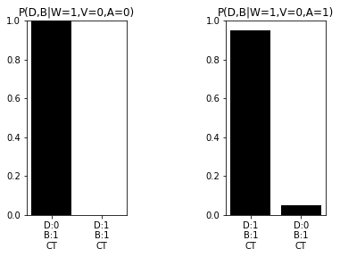

```python
def figure_2_c_CT():
    # Fix these to the values we care about
    w = 1
    v = 0
    theory = CT_THEORY
    for a in [0, 1]:
        # Compute the probabilities we care about by sampling from P(_ | W=1, V=1, A=a, Theory=CT_THEORY)
        # This time we use the CT_model_code, because if we use the joint_model_code we get a
        # "JagsError: Error in node E_gamma\n Cannot normalize density" ! (Try this by toggling the two lines below)
        model = pyjags.Model(CT_model_code, data=dict(W=w, V=v, A=a), chains=4, adapt=1000)
        # model = pyjags.Model(joint_model_code, data=dict(W=w, V=v, A=a, Theory=theory), chains=4, adapt=1000)
        samples = model.sample(1000, vars=['D', 'B'])
        if a == 0:
            Prob_D0_B1_A0 = np.mean((samples['D'] == 0) & (samples['B'] == 1))
            Prob_D1_B1_A0 = np.mean((samples['D'] == 1) & (samples['B'] == 1))
        elif a == 1:
            Prob_D1_B1_A1 = np.mean((samples['D'] == 1) & (samples['B'] == 1))
            Prob_D0_B1_A1 = np.mean((samples['D'] == 0) & (samples['B'] == 1))
    probs_to_show_A0 = [Prob_D0_B1_A0,
                        Prob_D1_B1_A0]
    probs_to_show_A1 = [Prob_D1_B1_A1,
                        Prob_D0_B1_A1]

    # Do the plots
    plt.subplot(1, 2, 1)
    plt.title("P(D,B|W=1,V=0,A=0)")
    plt.bar(height=probs_to_show_A0, x=('D:0\nB:1\nCT', 'D:1\nB:1\nCT'), color='k')
    plt.ylim((0, 1))

    plt.subplot(1, 2, 2)
    plt.title("P(D,B|W=1,V=0,A=1)")
    plt.bar(height=probs_to_show_A1, x=('D:1\nB:1\nCT', 'D:0\nB:1\nCT'), color='k')
    plt.ylim((0, 1))

    plt.subplots_adjust(wspace=1)

figure_2_c_CT()
```

## Figure 2 (c), PT

[figure not shown]

# Code

```
adapting: iterations 4000 of 4000, elapsed 0:00:00, remaining 0:00:00
sampling: iterations 4000 of 4000, elapsed 0:00:00, remaining 0:00:00
adapting: iterations 4000 of 4000, elapsed 0:00:00, remaining 0:00:00
sampling: iterations 4000 of 4000, elapsed 0:00:00, remaining 0:00:00
```

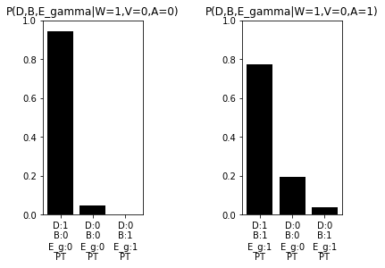

```python
def figure_2_c_PT():
    # Fix these to the values we care about
    w = 1
    v = 0
    theory = PT_THEORY
    for a in [0, 1]:
        # Compute the probabilities we care about by sampling from P(_ | W=1, V=1, A=a, Theory=PT_THEORY)
        model = pyjags.Model(PT_model_code, data=dict(W=w, V=v, A=a), chains=4, adapt=1000)
        samples = model.sample(1000, vars=['D', 'B', 'E_gamma'])
        if a == 0:
            Prob_D1_B0_EGamma0_A0 = np.mean((samples['D'] == 1) & (samples['B'] == 0) & (samples['E_gamma'] == 0))
            Prob_D0_B0_EGamma0_A0 = np.mean((samples['D'] == 0) & (samples['B'] == 0) & (samples['E_gamma'] == 0))
            Prob_D0_B1_EGamma1_A0 = np.mean((samples['D'] == 1) & (samples['B'] == 1) & (samples['E_gamma'] == 1))
        elif a == 1:
            Prob_D1_B1_EGamma1_A1 = np.mean((samples['D'] == 1) & (samples['B'] == 1) & (samples['E_gamma'] == 1))
            Prob_D0_B0_EGamma0_A1 = np.mean((samples['D'] == 0) & (samples['B'] == 0) & (samples['E_gamma'] == 0))
            Prob_D0_B1_EGamma1_A1 = np.mean((samples['D'] == 0) & (samples['B'] == 1) & (samples['E_gamma'] == 1))
    probs_to_show_A0 = [Prob_D1_B0_EGamma0_A0,
                        Prob_D0_B0_EGamma0_A0,
                        Prob_D0_B1_EGamma1_A0]
    probs_to_show_A1 = [Prob_D1_B1_EGamma1_A1,
                        Prob_D0_B0_EGamma0_A1,
                        Prob_D0_B1_EGamma1_A1]

    # Do the plots
    plt.subplot(1, 2, 1)
    plt.title("P(D,B,E_gamma|W=1,V=0,A=0)")
    plt.bar(height=probs_to_show_A0, x=('D:1\nB:0\nE_g:0\nPT', 'D:0\nB:0\nE_g:0\nPT', 'D:0\nB:1\nE_g:1\nPT'), color='k')
    plt.ylim((0, 1))

    plt.subplot(1, 2, 2)
    plt.title("P(D,B,E_gamma|W=1,V=0,A=1)")
    plt.bar(height=probs_to_show_A1, x=('D:1\nB:1\nE_g:1\nPT', 'D:0\nB:0\nE_g:0\nPT', 'D:0\nB:1\nE_g:1\nPT'), color='k')
    plt.ylim((0, 1))

    plt.subplots_adjust(wspace=1)

figure_2_c_PT()
```

# Figure 2 (d)

[figure not shown]

# What is surprise?

For each of the outcomes of the False Belief test - $A = 0$ and $A = 1$ - there is a corresponding most likely explanation. This plot shows from the perspective of each model how surprising it is for the variables $D$, $B$, and $E_\gamma$ to take on these values unconditionally on $A$ (that is, before the result of the experiment is revealed to the child, so: only conditioned on $W=1, V=0, Theory$).

The definition of surprise is as follows: Given $(\Omega, \Sigma, P)$ a probability space and $E \in \Sigma$ an event, we define the *surprise* of event $E$ as:

$$\text{surprise}(E) = -\log P(E)$$

This way, we need to compute:

$$-\log P(X=x\ |\ W=1,\ V=0,\ Theory)$$

for each $(X, x) \in \{(D, 1), (B, 0), (E_\gamma, 0), (D, 1), (E_\gamma, 1)\}$.

Again, this requires marginalizing out many unwanted variables, such as $\gamma, \epsilon, B, A$ and $E_\gamma$ when computing the surprise of $D = 1$, so we use JAGS to draw samples from the conditional distribution of interest to compute these marginals. Again, we use 4 chains with 1000 burn-in steps and draw 1000 samples.

# Figure 2 (d), CT

[figure not shown]

# Code

```
sampling: iterations 4000 of 4000, elapsed 0:00:00, remaining 0:00:00
```

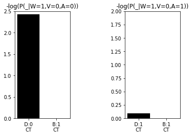

```python
def figure_2_d_CT():
    # Fix these to the values we care about
    w = 1
    v = 0
    theory = CT_THEORY
    # Draw samples from P( _ | W=1, V=0, Theory=CT_THEORY)
    model = pyjags.Model(CT_model_code, data=dict(W=w, V=v), chains=4, adapt=1000)
    samples = model.sample(1000, vars=['D', 'B'])

    Surp_D0 = -np.log(np.mean(samples['D'] == 0))
    Surp_B1 = -np.log(np.mean(samples['B'] == 1))
    Surp_D1 = -np.log(np.mean(samples['D'] == 1))

    surps_to_show_A0 = [Surp_D0,
                        Surp_B1]
    surps_to_show_A1 = [Surp_D1,
                        Surp_B1]

    # Do the plots
    plt.subplot(1, 2, 1)
    plt.title("-log(P(_|W=1,V=0,A=0))")
    plt.bar(height=surps_to_show_A0, x=('D:0\nCT', 'B:1\nCT'), color='k')
    plt.ylim((0, 2.5))

    plt.subplot(1, 2, 2)
    plt.title("-log(P(_|W=1,V=0,A=1))")
    plt.bar(height=surps_to_show_A1, x=('D:1\nCT', 'B:1\nCT'), color='k')
    plt.ylim((0, 2))

    plt.subplots_adjust(wspace=1)

figure_2_d_CT()
```

# Figure 2 (d), PT

[figure not shown]

# Code

```
sampling: iterations 4000 of 4000, elapsed 0:00:00, remaining 0:00:00
```

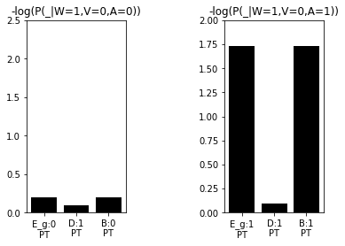

```python
def figure_2_d_PT():
    # Fix these to the values we care about
    w = 1
    v = 0
    theory = PT_THEORY
    # Draw samples from P( _ | W=1, V=0, Theory=PT_THEORY)
    model = pyjags.Model(PT_model_code, data=dict(W=w, V=v), chains=4, adapt=1000)
    samples = model.sample(1000, vars=['D', 'B', 'E_gamma'])

    Surp_EGamma0 = -np.log(np.mean(samples['E_gamma'] == 0))
    Surp_D1 = -np.log(np.mean(samples['D'] == 1))
    Surp_B0 = -np.log(np.mean(samples['B'] == 0))
    Surp_EGamma1 = -np.log(np.mean(samples['E_gamma'] == 1))
    Surp_B1 = -np.log(np.mean(samples['B'] == 1))

    surps_to_show_A0 = [Surp_EGamma0,
                        Surp_D1,
                        Surp_B0]
    surps_to_show_A1 = [Surp_EGamma1,
                        Surp_D1,
                        Surp_B1]

    # Do the plots
    plt.subplot(1, 2, 1)
    plt.title("-log(P(_|W=1,V=0,A=0))")
    plt.bar(height=surps_to_show_A0, x=('E_g:0\nPT', 'D:1\nPT', 'B:0\nPT'), color='k')
    plt.ylim((0, 2.5))

    plt.subplot(1, 2, 2)
    plt.title("-log(P(_|W=1,V=0,A=1))")
    plt.bar(height=surps_to_show_A1, x=('E_g:1\nPT', 'D:1\nPT', 'B:1\nPT'), color='k')
    plt.ylim((0, 2))

    plt.subplots_adjust(wspace=1)

figure_2_d_PT()
```

# Figure 3

[figure not shown]

This figure shows that as the child (acting under the paper's model) is exposed to more and more experience (10 epochs of the same experience, to be precise), a natural transition happens from the CT model to the PT model.

Each batch of experience corresponds to twenty $(W=1, V=1, A=1)$ pairs, six $(W=1, V=0, A=1)$ pairs, and one $(W=1, V=0, A=0)$ pair. The reasons that the paper gives for using these pairs is that:

Despite the fact that each epoch has 6 examples in favor of the CT model and only 1 example in favor of the PT model, the authors argue - and demostrate through this figure - that as more experience is collected (in the form of epochs), since surprising outcomes weight more heavily against the CT model (because it is simpler), after enough epochs belief shifts from the CT model to the PT model. This is just the result of Occam's Razor through the lens of Probability Theory.

For this figure, we must compute the log-posterior odds ratio. That is, we must compute:

$$W_{PT/CT} = \log \frac{P(Theory=PT\_THEORY | X)}{P(Theory=CT\_THEORY | X)}$$

where:

\begin{align*} X = & \{W=1,V=1,A=1\}\text{ $20\ \times $ epoch times}, \\ &\{W=1,V=0,A=1\}\text{ $6\ \times $ epoch times}, \\ &\{W=1,V=0,A=0\}\text{ $1\ \times $ epoch times} \end{align*}

To do this, we could use JAGS to draw samples from the conditional probability $P( \_ | X)$ and then just count how many times we saw $Theory=CT\_THEORY$ and $Theory=PT\_THEORY$. However, Gibbs sampling fails terribly if we do not condition on $Theory$, because the probability distribution is markedly bimodal (more on this later!)

Instead, (assuming a uniform prior over $Theory$), we will rewrite:

$$\log \frac{P(Theory=PT\_THEORY | X)}{P(Theory=CT\_THEORY | X)} = \log \frac{P(X\ |\ Theory=PT\_THEORY)}{P(X\ |\ Theory=CT\_THEORY)}$$

And thus we only need to compute $P(X\ |\ Theory=theory)$. We compute this as an integral:

\begin{equation} P(X\ |\ Theory=theory) = \int P(X\ |\ \epsilon,\ \gamma,\ Theory=theory)\ P(\epsilon,\ \gamma)\ d\epsilon\ d\gamma \end{equation}

We take advantage of the fact that the inner term $P(X\ |\ \epsilon,\ \gamma,\ Theory=theory)$ is easy to compute. Indeed, by conditional independance:

$$P(X\ |\ \epsilon,\ \gamma,\ Theory=theory) = \prod_{(w_i, v_i, a_i) \in X} P(W = w_i,\ V = v_i,\ A = a_i\ | \ \epsilon,\ \gamma,\ Theory=theory)$$

and

$$P(W = w_i,\ V = v_i,\ A = a_i\ | \ \epsilon,\ \gamma,\ Theory=theory) = \\ \sum_{d = 0}^1 \sum_{b = 0}^1 P(W = w_i,\ V = v_i,\ A = a_i,\ D = d,\ B = b\ | \ \epsilon,\ \gamma,\ Theory=theory)$$

which we can compute exactly with:

\begin{align} P(W = w_i,&\ V = v_i,\ A = a_i, \ D = d,\ B = b\ | \ \epsilon,\ \gamma,\ Theory=theory) = \\ & P(W = w_i) \\ \times\ & P(V = v_i) \\ \times\ & P(D = d\ | \ \epsilon,\ Theory=theory) \\ \times\ & P(B = b\ | \ W = w_i,\ V = v_i,\ \gamma,\ Theory=theory) \\ \times\ & P(A = a_i\ | \ D = d,\ B = b,\ Theory=theory) \end{align}

Note that since $W$ and $V$ are root variables in our graph which are always observed (in fact, their prior probability is never specified in the paper), we can drop the terms $P(W = w_i)$ and $P(V = v_i)$ from the above equation (while still arriving at the correct log-posterior odds ratio).

To deal with the fact that $\epsilon$ and $\gamma$ are continuous, we approximate the integral with a grid. That is, we compute instead:

\begin{equation} P(X\ |\ Theory=theory) \cong \\ \frac{1}{|\text{grid_epsilon}||\text{grid_gamma}|} \sum_{\epsilon \in \text{grid_epsilon}} \sum_{\gamma \in \text{grid_gamma}} P(X\ |\ \epsilon,\ \gamma,\ Theory=theory)\ P(\epsilon,\ \gamma)\ d\epsilon\ d\gamma \end{equation}

Since the probabilities we are computing are negligibly small, to avoid numerical stability issues we compute the log probability using the trick:

$$\log \Big( \sum_{i = 1}^n e^{x_i} \Big) = \Big(\max_j x_j\Big) + \log \Big( \sum_{i = 1}^n e^{x_i - \max_j x_j} \Big)$$

```python
def prob_B_given_W_V_Gamma_Theory(b, w, v, gamma, theory):
    r"""
    Compute P(B=b | W=w, V=v, Gamma=gamma, Theory=theory)
    """
    if theory == CT_THEORY:
        if b == w:
            return 1.0
        elif b != w:
            return 0.0
    elif theory == PT_THEORY:
        if v == 0:
            if b == 1:
                return gamma
            else:
                return 1.0 - gamma
        elif v == 1:
            if b == w:
                return 1.0
            elif b != w:
                return 0.0

def prob_D_given_Epsilon_Theory(d, epsilon, theory):
    r"""
    Compute P(D=d | Epsilon=epsilon, Theory=theory)
    """
    if d == 0:
        return epsilon
    elif d == 1:
        return 1.0 - epsilon

def prob_A_given_B_D_Theory(a, d, b, theory):
    r"""
    Compute P(A=a | D=d, B=b, Theory=theory)
    """
    if d == 0:
        # No desire, equal prob independently of a
        return 0.5
    elif d == 1:
        # Looks where she believes the item is.
        return (a == b) * 1.0

def prob_W_V_A_given_Theory_Epsilon_Gamma(w, v, a, theory, epsilon, gamma):
    r"""
    Compute P(w, v, a | theory, epsilon, gamma).
    """
    res = 0.0
    for b in [0, 1]:
        for d in [0, 1]:
            res += prob_D_given_Epsilon_Theory(d,
                                               epsilon, theory) * \
                   prob_B_given_W_V_Gamma_Theory(b,
                                                 w, v, gamma, theory) * \
                   prob_A_given_B_D_Theory(a,
                                           d, b, theory)
    return res
```

```python
def log_prob_epoch_given_Theory_Epsilon_Gamma(theory, epsilon, gamma, k_1, k_2, k_3):
    r"""
    Compute Log P({W=1,V=1,A=1}_{k_1 times}, {W=1,V=0,A=1}_{k_2 times}, {W=1,V=0,A=0}_{k_3 times} | theory, epsilon, gamma)
    exactly.
    """
    log_prob_W1_V1_A1 = np.log(prob_W_V_A_given_Theory_Epsilon_Gamma(1, 1, 1, theory, epsilon, gamma))
    log_prob_W1_V0_A1 = np.log(prob_W_V_A_given_Theory_Epsilon_Gamma(1, 0, 1, theory, epsilon, gamma))
    log_prob_W1_V0_A0 = np.log(prob_W_V_A_given_Theory_Epsilon_Gamma(1, 0, 0, theory, epsilon, gamma))
    return k_1 * log_prob_W1_V1_A1 + k_2 * log_prob_W1_V0_A1 + k_3 * log_prob_W1_V0_A0
```

```python
def log_prob_for_each_theory_and_epoch_with_grid_approximation(
    GRID_SIZE_EPSILON = 40,
    GRID_SIZE_GAMMA = 40,
    EPOCHS = 10):
    r"""
    Compute Log P(X | Theory=theory) for each theory and for all epochs from 0 to EPOCHS.
    :param GRID_SIZE_EPSILON: Size of grid for epsilon used to approximate the integral.
    :param GRID_SIZE_GAMMA: Size of grid for gamma used to approximate the integral.
    :param EPOCHS: Number of epochs to compute probabilities up to.
    :return res: np.array of dimension (2, EPOCHS + 1) where res[theory][epoch] = Log P(X | Theory=theory)
                 where X has 'epoch' epochs.
    """
    grid_epsilon = np.array(range(1,2 * GRID_SIZE_EPSILON,2)) / (2 * GRID_SIZE_EPSILON)
    grid_gamma = np.array(range(1,2 * GRID_SIZE_GAMMA,2)) / (2 * GRID_SIZE_GAMMA)
    log_prob_theory_epoch = np.zeros((2, EPOCHS + 1))
    for theory in [CT_THEORY, PT_THEORY]:
        log_prob_terms_theory_epoch = [[] for i in range(EPOCHS + 1)]
        for epsilon in grid_epsilon:
            for gamma in grid_gamma:
                # Compute Log P(X | epsilon, gamma, Theory=theory) for only 1 epoch
                # (for more epochs we just multiply this number by the number of epochs)
                log_prob_term_theory_epsilon_gamma_1_epoch = log_prob_epoch_given_Theory_Epsilon_Gamma(theory, epsilon, gamma, k_1=20, k_2=6, k_3=1)
                # Compute Log P(X | epsilon, gamma, Theory=theory) for only all epoch,
                # which just means multiplying the result for 1 epoch by the number of epochs.
                for epoch in range(1, EPOCHS + 1):
                    prob_epsilon_gamma = beta.pdf(epsilon, 1, 10) * beta.pdf(gamma, 1, 5)
                    log_prob_term_theory_epoch = epoch * log_prob_term_theory_epsilon_gamma_1_epoch + np.log(prob_epsilon_gamma)
                    log_prob_terms_theory_epoch[epoch].append(log_prob_term_theory_epoch)
        # Compute Log P(X | Theory=theory) for each epoch in a numerically stable way.
        for epoch in range(1, EPOCHS + 1):
            max_log_prob_term_theory_epoch = max(log_prob_terms_theory_epoch[epoch])
            sum_of_products = 0
            for log_prob_term_theory_epoch in log_prob_terms_theory_epoch[epoch]:
                sum_of_products += np.exp(log_prob_term_theory_epoch - max_log_prob_term_theory_epoch)
            log_prob_theory_epoch[theory, epoch] = np.log(1.0 / (GRID_SIZE_EPSILON * GRID_SIZE_GAMMA) * sum_of_products) + max_log_prob_term_theory_epoch
    return log_prob_theory_epoch
```

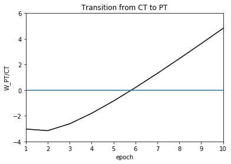

```python
EPOCHS = 10
log_prob_epoch = log_prob_for_each_theory_and_epoch_with_grid_approximation(
    GRID_SIZE_EPSILON = 40,
    GRID_SIZE_GAMMA = 40,
    EPOCHS = EPOCHS)
W_PT_CT = [log_prob_epoch[PT_THEORY][i] - log_prob_epoch[CT_THEORY][i] for i in range(EPOCHS + 1)]
plt.plot(W_PT_CT, color='k')
plt.title("Transition from CT to PT")
plt.xlim((1,10))
plt.xlabel("epoch")
plt.ylabel("W_PT/CT")
plt.ylim((-4,6))
plt.axhline(y=0)
plt.show()
```

This transition is just a manifestation of the following lemma:

Let $f, g : K = [0, 1]^n \rightarrow \mathbb R_{\ge 0}$ be continuous, non-zero functions such that $\max f > \max g$, and let $p : K = [0, 1]^n \rightarrow \mathbb R_{> 0}$ be continuous. Then:

$$\lim_{k \rightarrow \infty} \frac{\int_{K} f^k p}{\int_{K} g^k p} = \infty$$

In our setting we have that $f(\epsilon, \gamma) = P(\text{one epoch of $X$}\ |\ \epsilon,\ \gamma,\ Theory = \text{PT_Theory})$ and analogously $g$ is defined for CT Theory; $p$ is just the density of the joint distribution of $(\epsilon, \gamma)$.

Note that

$$P(\text{$k$ epochs of $X$}\ |\ \epsilon,\ \gamma,\ Theory = theory) = [P(\text{one epoch of $X$}\ |\ \epsilon,\ \gamma,\ Theory = theory)]^k$$

whence the lemma implies the transition from CT to PT will happen inevitably.

So, essentially, if one model has a better setting of hyperparameters, then under repeated evidence it will become the most likely one (so that maximum likelihood estimation and bayesian inference agree).

# Figure 3: The Need for Approximate Integration

[figure not shown]

Let's try to reproduce the figure by just running a gibbs chain on $P(\_| X)$. We will see it fails! We argue this is because $P(\_| X)$ is bimodal.

To give evidence for the bimodality of $P(\_| X)$, we show that a Gibbs chains conveniently initialized on the mode of each theory will stay there for a very long time (likely for exponentially long time before moving on to the other mode).

```python
joint_model_code = """
model {
    Theory ~ dbern(0.5)

    Epsilon ~ dbeta(1,10)
    Gamma ~ dbeta(1,5)

    for(i in 1:N){
        B[i] ~ dbern( Theory * (Gamma * (1 - V[i]) + V[i] * W[i]) + (1 - Theory) * (W[i]) )
        D[i] ~ dbern(1 - Epsilon)
        A[i] ~ dbern(0.5 * (1 - D[i]) + D[i] * B[i])
    }
}"""
```

```python
k_1 = 20
k_2 = 6
k_3 = 1

def calc_figure_3_probs_with_jags_initialized_with(Theory0, D0, B0, EPOCHS):
    r"""
    For each number of EPOCHS, runs a Gibbs chain on P(_|X) initialized on
    Theory = Theory0, D = D0, B = B0.
    :return df: DataFrame with one row for each epoch. Each row correspons to
    ('epoch', 'posteriorProbCT', 'posteriorProbPT')
    :return all_samples: List of length EPOCHS, where all_samples[i] contains the
    samples from jags for the model conditioned on i epochs of data.
    """
    df = pd.DataFrame(columns = ['epoch', 'posteriorProbCT', 'posteriorProbPT'])

    all_samples = []

    for epoch in range(1, EPOCHS + 1):
        Theory = Theory0
        W = [1] * k_1 + [1] * k_2 + [1] * k_3
        V = [1] * k_1 + [0] * k_2 + [0] * k_3
        A = [1] * k_1 + [1] * k_2 + [0] * k_3
        D = D0[:]
        B = B0[:]

        N = len(W)

        W = W * epoch
        V = V * epoch
        A = A * epoch
        D = D * epoch
        B = B * epoch
        N = N * epoch

        model = pyjags.Model(joint_model_code, data=dict(N=N, W=W, V=V, A=A), init=dict(D=D, B=B, Theory=Theory), chains=4, adapt=1000)

        samples = model.sample(10000, vars=['Theory', 'D', 'B'])

        all_samples.append(samples)

        df = df.append({'epoch': epoch,
                        'posteriorProbCT': np.mean(samples['Theory'] == CT_THEORY),
                        'posteriorProbPT': np.mean(samples['Theory'] == PT_THEORY)},
                      ignore_index=True)

    return df, all_samples
```

## Initializing the chain on the CT Mode

By looking at the plots of Figure 2 (c), we see that, under the CT model:

- For $(W = 1, V = 1, A = 1)$, the most likely explanation is $(D = 1, B = 1)$.
- For $(W = 1, V = 0, A = 1)$, the most likely explanation is $(D = 1, B = 1)$.
- For $(W = 1, V = 0, A = 0)$, the most likely explanation is $(D = 0, B = 1)$.

We therefore initialize the chains on these values, hoping to make the chain get stuck in the CT mode.

```python
probs_CT, samples_CT = calc_figure_3_probs_with_jags_initialized_with(
    Theory0 = 0,
    D0 = [1] * k_1 + [1] * k_2 + [0] * k_3,
    B0 = [1] * k_1 + [1] * k_2 + [1] * k_3,
    EPOCHS = 10)
probs_CT
```

[output not shown]

|  | epoch | posteriorProbCT | posteriorProbPT |
| --- | --- | --- | --- |
| 0 | 1.0 | 0.962250 | 0.037750 |
| 1 | 2.0 | 0.892675 | 0.107325 |
| 2 | 3.0 | 0.999975 | 0.000025 |
| 3 | 4.0 | 1.000000 | 0.000000 |
| 4 | 5.0 | 1.000000 | 0.000000 |
| 5 | 6.0 | 1.000000 | 0.000000 |
| 6 | 7.0 | 1.000000 | 0.000000 |
| 7 | 8.0 | 1.000000 | 0.000000 |
| 8 | 9.0 | 1.000000 | 0.000000 |
| 9 | 10.0 | 1.000000 | 0.000000 |

## Initializing the chain on the PT Mode

By looking at the plots of Figure 2 (c), we see that, under the PT model:

- For $(W = 1, V = 1, A = 1)$, the most likely explanation is $(D = 1, B = 1)$.
- For $(W = 1, V = 0, A = 1)$, the most likely explanation is $(D = 1, B = 1)$.
- For $(W = 1, V = 0, A = 0)$, the most likely explanation is $(D = 1, B = 0)$.

Notice that the CT and PT model agree on the explanations of *all* outcomes, except for the standard outcome, where CT explains with $(D = 0, B = 1)$ and PT explains with $(D = 1, B = 0)$. Moreover, the probability that the CT model assigns to $(D = 1, B = 0)$ is literally *zero*, and the probability that the PT model assigns to $(D = 0, B = 1)$ is close to zero. This, we claim, in the source of bimodality, as moving from one mode to the other requires the Gibbs chain to change the values of many $(D, B)$ pairs (in fact *all* pairs, when moving from the PT mode to the CT mode, because of the previous observation!)

We therefore initialize the chains on these values, hoping to make the chain get stuck in the PT mode.

```python
probs_PT, samples_PT = calc_figure_3_probs_with_jags_initialized_with(
    Theory0 = 1,
    D0 = [1] * k_1 + [1] * k_2 + [1] * k_3,
    B0 = [1] * k_1 + [1] * k_2 + [0] * k_3,
    EPOCHS = 10)
probs_PT
```

[output not shown]

|  | epoch | posteriorProbCT | posteriorProbPT |
| --- | --- | --- | --- |
| 0 | 1.0 | 0.961750 | 0.038250 |
| 1 | 2.0 | 0.872025 | 0.127975 |
| 2 | 3.0 | 0.268925 | 0.731075 |
| 3 | 4.0 | 0.000000 | 1.000000 |
| 4 | 5.0 | 0.000000 | 1.000000 |
| 5 | 6.0 | 0.000000 | 1.000000 |
| 6 | 7.0 | 0.000000 | 1.000000 |
| 7 | 8.0 | 0.000000 | 1.000000 |
| 8 | 9.0 | 0.000000 | 1.000000 |
| 9 | 10.0 | 0.000000 | 1.000000 |

## Let's look at the marginal over (D, B) of the chains...

If our intuition is correct, we should see the marginal over (D,B) which correspond to the standard outcome concentrate on $(D = 0, B = 1)$ for the CT model and $(D = 1, B = 0)$ for the PT model.

```python
def compute_marginal_over_D_and_B(samples):
    r"""
    Given samples from the gibbs chains (corresponding to only one epoch!),
    computes the 2x2 matrix of marginals over (D, B) pairs corresponding
    to the standard outcome, that is:
    P((D, B) = (d, b) for the standard outcome | X)
    """
    indices_of_standard_outcome = []
    for i in range(len(samples['D'])):
        if (i % 27) in [26]:
            indices_of_standard_outcome.append(i)
    res = np.zeros((2, 2))
    for d in range(2):
        for b in range(2):
            res[d, b] = np.mean((samples['D'][indices_of_standard_outcome] == d) & (samples['B'][indices_of_standard_outcome] == b))
    return res
```

```python
def plot_marginal_over_D_and_B(marginal, title):
    sns.heatmap(marginal,
                linewidth=0.5,
                vmin=0.0,
                vmax=1.0,
                annot=True,
                fmt='.5f',
                square=True,
                xticklabels=["B:0", "B:1"],
                yticklabels=["D:0", "D:1"],
                cmap='Greys')
    plt.title(title)
    plt.show()
```

## CT marginal

This should concentrate on $(D = 0, B = 1)$.

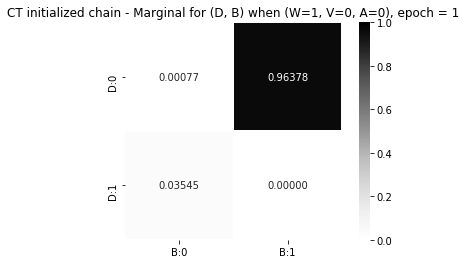

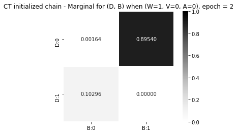

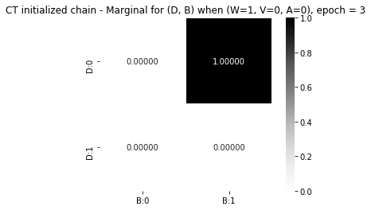

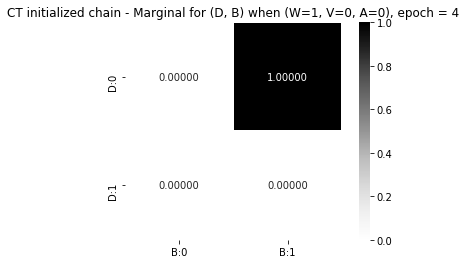

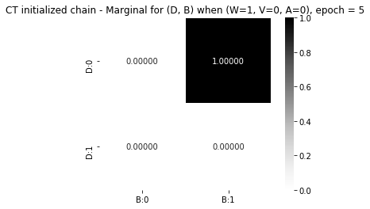

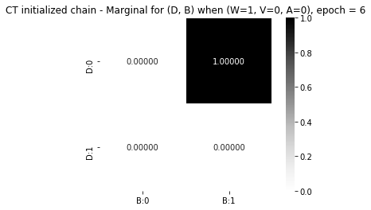

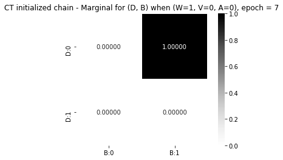

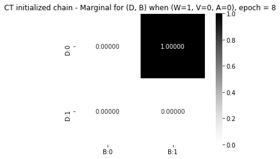

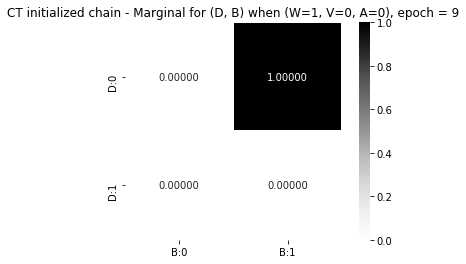

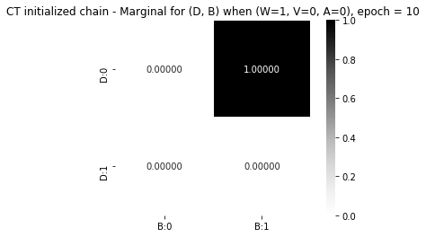

```python
marginals_over_D_and_B_CT = [compute_marginal_over_D_and_B(samples) for samples in samples_CT]
for epoch in range(len(marginals_over_D_and_B_CT)):
    plot_marginal_over_D_and_B(marginals_over_D_and_B_CT[epoch], title=f"CT initialized chain - Marginal for (D, B) when (W=1, V=0, A=0), epoch = {epoch + 1}")
```

## PT marginal

This should concentrate on $(D = 1, B = 0)$.

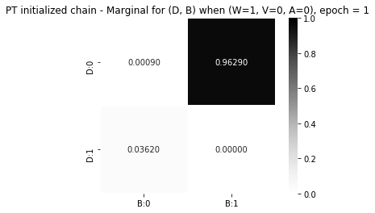

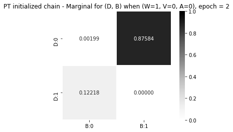

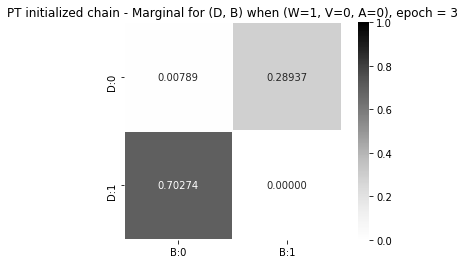

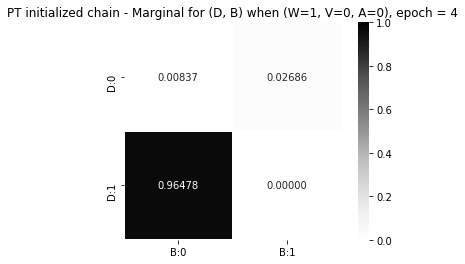

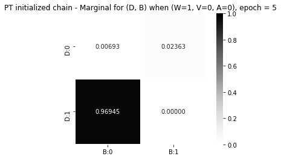

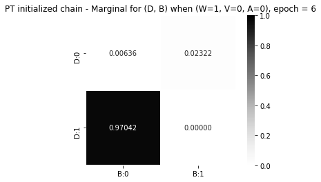

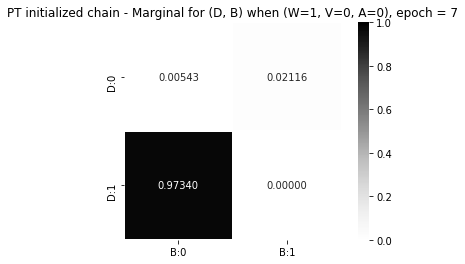

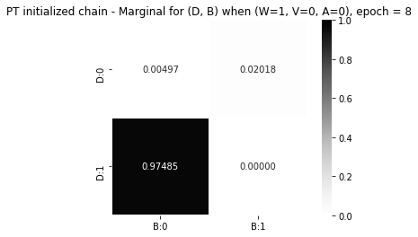

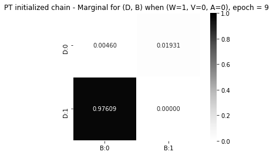

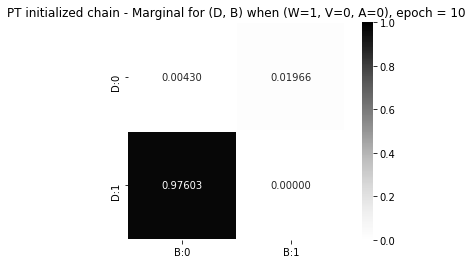

```python
marginals_over_D_and_B_PT = [compute_marginal_over_D_and_B(samples) for samples in samples_PT]
for epoch in range(len(marginals_over_D_and_B_PT)):
    plot_marginal_over_D_and_B(marginals_over_D_and_B_PT[epoch], title=f"PT initialized chain - Marginal for (D, B) when (W=1, V=0, A=0), epoch = {epoch + 1}")
```